# credit score

```python
import pandas as pd
import numpy as np
import scipy as sp
import seaborn as sns
import matplotlib.pyplot as plt
from sklearn.linear_model import LogisticRegression
from sklearn.model_selection import GridSearchCV, KFold, cross_val_predict
from sklearn.preprocessing import StandardScaler
from sklearn.feature_selection import SelectKBest,  f_classif
from sklearn.pipeline import Pipeline
```

```python
pd.options.display.float_format = '{:,.15f}'.format
```

```python
train_df = pd.read_csv("train.csv")
train_df.head()
```

|  | order_id | cred_sum_cc_all | mfo_inqs_count_month | all_closed_creds_sum_all | bank_inqs_count_quarter | cred_max_overdue_max_ly | all_active_creds_sum_all | mfo_last_days_all | cred_sum_cc_ly | cred_sum_debt_all_all | ... | cred_max_overdue_max_3lm | mfo_closed_count_ly | cred_sum_overdue_cc_all | count_overdue_all_3lm | all_creds_count_lm | work_code | month_income | region | bad | approved |
| --- | --- | --- | --- | --- | --- | --- | --- | --- | --- | --- | --- | --- | --- | --- | --- | --- | --- | --- | --- | --- | --- |
| 0 | 5498546 | 0.000000000000000 | 0 | 40364 | 0 | 0.000000000000000 | 3000 | 560 | 0.000000000000000 | 0.000000000000000 | ... | 0.000000000000000 | 0 | 0.000000000000000 | 0 | 0 | 3 | 50000 | 46 | NaN | 0 |
| 1 | 5498604 | 1,500.000000000000000 | 0 | 23456 | 0 | 0.000000000000000 | 0 | 9999 | 0.000000000000000 | 0.000000000000000 | ... | 0.000000000000000 | 0 | 0.000000000000000 | 0 | 0 | 3 | 35000 | 17 | NaN | 0 |
| 2 | 5498609 | 0.100000000000000 | 0 | 17999 | 3 | 0.000000000000000 | 9999 | 9999 | 0.100000000000000 | 9,999.000000000000000 | ... | 0.000000000000000 | 0 | 0.000000000000000 | 0 | 2 | 3 | 35000 | 58 | NaN | 0 |
| 3 | 5498645 | 5,000.000000000000000 | 0 | 313247 | 0 | 0.000000000000000 | 0 | 9999 | 0.000000000000000 | 0.000000000000000 | ... | 0.000000000000000 | 0 | 4,923.970000000000255 | 0 | 0 | 5 | 35000 | 4 | NaN | 0 |
| 4 | 5498647 | 0.000000000000000 | 0 | 0 | 1 | 0.000000000000000 | 0 | 9999 | 0.000000000000000 | 0.000000000000000 | ... | 0.000000000000000 | 0 | 0.000000000000000 | 0 | 0 | 5 | 35000 | 34 | NaN | 0 |

5 rows × 25 columns

```python
test_df = pd.read_csv("test.csv")
test_df.head()
```

|  | order_id | cred_sum_cc_all | mfo_inqs_count_month | all_closed_creds_sum_all | bank_inqs_count_quarter | cred_max_overdue_max_ly | all_active_creds_sum_all | mfo_last_days_all | cred_sum_cc_ly | cred_sum_debt_all_all | ... | cred_max_overdue_max_3lm | mfo_closed_count_ly | cred_sum_overdue_cc_all | count_overdue_all_3lm | all_creds_count_lm | work_code | month_income | region | bad | approved |
| --- | --- | --- | --- | --- | --- | --- | --- | --- | --- | --- | --- | --- | --- | --- | --- | --- | --- | --- | --- | --- | --- |
| 0 | 5499904 | 16,000.000000000000000 | 0 | 6890 | 1 | 33,722.120000000002619 | 33722 | 9999 | 0.000000000000000 | 0.000000000000000 | ... | 0.000000000000000 | 0 | 0.000000000000000 | 0 | 0 | 5 | 35000 | 65 | NaN | 0 |
| 1 | 5501986 | 0.000000000000000 | 0 | 0 | 5 | 5,000.000000000000000 | 0 | 289 | 0.000000000000000 | 0.000000000000000 | ... | 0.000000000000000 | 0 | 0.000000000000000 | 0 | 0 | 3 | 35000 | 7 | NaN | 0 |
| 2 | 5503586 | 133,000.000000000000000 | 1 | 284685 | 9 | 16,600.000000000000000 | 716305 | 6 | 50,000.000000000000000 | 593,315.329999999958090 | ... | 16,600.000000000000000 | 4 | 2,409.329999999999927 | 1 | 4 | 4 | 50000 | 18 | 1.000000000000000 | 1 |
| 3 | 5507043 | 10,000.000000000000000 | 0 | 0 | 0 | 0.000000000000000 | 0 | 9999 | 0.000000000000000 | 0.000000000000000 | ... | 0.000000000000000 | 0 | 9,968.840000000000146 | 0 | 0 | 5 | 20000 | 58 | NaN | 0 |
| 4 | 5512692 | 120,500.000000000000000 | 0 | 1293089 | 8 | 9,605.180000000000291 | 1562678 | 33 | 0.000000000000000 | 1,392,907.340000000083819 | ... | 1,221.809999999999945 | 1 | 4,442.420000000000073 | 1 | 0 | 3 | 50000 | 20 | 0.000000000000000 | 1 |

5 rows × 25 columns

## Анализ данных

Сравнить распределение каждого признака на выборке выданных кредитов (bad != nan или approved == 1) с распределением этого же признака на всей выборке.

```python
approv_df = train_df[train_df['approved'] == 1].reset_index(drop=True)
approv_df.head()
```

|  | order_id | cred_sum_cc_all | mfo_inqs_count_month | all_closed_creds_sum_all | bank_inqs_count_quarter | cred_max_overdue_max_ly | all_active_creds_sum_all | mfo_last_days_all | cred_sum_cc_ly | cred_sum_debt_all_all | ... | cred_max_overdue_max_3lm | mfo_closed_count_ly | cred_sum_overdue_cc_all | count_overdue_all_3lm | all_creds_count_lm | work_code | month_income | region | bad | approved |
| --- | --- | --- | --- | --- | --- | --- | --- | --- | --- | --- | --- | --- | --- | --- | --- | --- | --- | --- | --- | --- | --- |
| 0 | 5499365 | 50,000.000000000000000 | 2 | 58500 | 14 | 0.000000000000000 | 38000 | 23 | 50,000.000000000000000 | 38,000.000000000000000 | ... | 0.000000000000000 | 5 | 0.000000000000000 | 0 | 2 | 1 | 35000 | 4 | 0.000000000000000 | 1 |
| 1 | 5499397 | 44,000.000000000000000 | 1 | 367842 | 3 | 24,000.000000000000000 | 74695 | 8 | 0.000000000000000 | 75,295.000000000000000 | ... | 0.000000000000000 | 11 | 0.000000000000000 | 0 | 3 | 2 | 35000 | 61 | 1.000000000000000 | 1 |
| 2 | 5499407 | 0.000000000000000 | 1 | 44500 | 0 | 0.000000000000000 | 5000 | 29 | 0.000000000000000 | 5,000.000000000000000 | ... | 0.000000000000000 | 7 | 0.000000000000000 | 0 | 1 | 4 | 50000 | 32 | 0.000000000000000 | 1 |
| 3 | 5499448 | 81,550.000000000000000 | 11 | 231604 | 5 | 0.000000000000000 | 272086 | 16 | 0.000000000000000 | 217,493.700000000011642 | ... | 0.000000000000000 | 4 | 0.000000000000000 | 0 | 4 | 5 | 35000 | 1 | 1.000000000000000 | 1 |
| 4 | 5499715 | 45,001.000000000000000 | 0 | 107584 | 0 | 5,975.239999999999782 | 267484 | 9999 | 1.000000000000000 | 244,351.869999999995343 | ... | 0.000000000000000 | 0 | 0.000000000000000 | 0 | 0 | 5 | 35000 | 78 | 0.000000000000000 | 1 |

5 rows × 25 columns

```python
def plot(field:str, df_to_compare:dict, function, by=None):
    """ Plot plots for dataframes from df_to_compare with function
    :param field_to_compare: field to compare
    :param df_to_compare: dictionary name -> dataframe
    :param function: function to plot df statistics
    """
    num_df = len(df_to_compare)

    if num_df == 0:
        return

    if num_df == 1:
        key = next(iter(df_to_compare.keys()))
        function(field, df_to_compare.get(key), by=by)
        plt.title(key)
        plt.show()
        return

    _, axs = plt.subplots(1, num_df, sharey='row')

    for i, (key, df) in enumerate(df_to_compare.items()):

        plt.subplot(1, num_df, i + 1)
        function(field, df)
        axs[i].set_title(key)

    plt.tight_layout()
    plt.show()


def plot_boxplot(field:str, df_to_compare:dict):
    plot(field, df_to_compare, boxplot)


def plot_hist(field:str, df_to_compare:dict, by=None):
    plot(field, df_to_compare, hist, by)


def boxplot(field, df, **kwargs):
    return df.boxplot(field, showfliers=False)


def hist(field, df, by=None):
    if by:
        return sns.histplot(data=df, x=field, hue=by, stat='count', edgecolor=None)
    return sns.histplot(data=df, x=field, stat='count', edgecolor=None)


df_to_compare = {
    "All orders": train_df,
    "Approved orders": approv_df
}
```

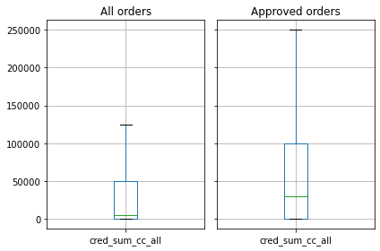

```python
field_to_compare = "cred_sum_cc_all"
plot_boxplot(field_to_compare, df_to_compare)
```

#### Сумма кредитов по кредитным картам

Сумма кредитов по кредитным картам выше в датасете, содержащем только тех, кому одобрили кредит, что логично. Тренировочный датасет содержит записи о тех, кому не одобрили кредит в данном банке, таким пользователям не одобрят кредит и в большенстве других банков. Следовательно первый датасет(по всем заявкам) по сравнению со вторым(только одобренные заявки) содержит информацию о тех, у кого мало или вообще нет кредитов. Засчет этого среднее значение на левом графике намного ниже, чем на правом.

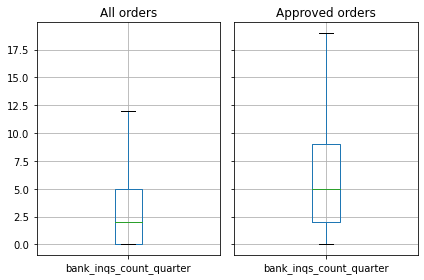

```python
field_to_compare = "bank_inqs_count_quarter"
plot_boxplot(field_to_compare, df_to_compare)
```

#### Количество запросов на кредиты в банки.

По графику мы можем сделать вывод, что те, кому одобрили кредит, не единожды подавали заявку в различные банки. У них есть опыт общения с банковскими служащими. Эти люди знают по опыту, каковы требования для получения кредитов.

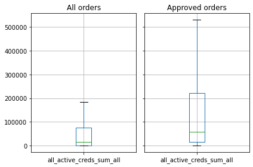

```python
field_to_compare = "all_active_creds_sum_all"
plot_boxplot(field_to_compare, df_to_compare)
```

#### Денежная сумма всех активных кредитов

На левом графике помимо тех, кому дали кредит, есть те, кому кредит не дали, поэтому и среднее, и разброс заначений меньше, чем на правом. На статистику влияют те, кому банк не доверяет и не одобрил кредит.

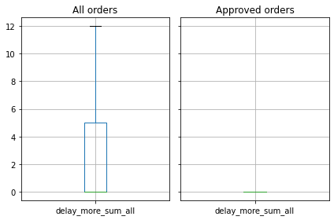

```python
field_to_compare = "delay_more_sum_all"
plot_boxplot(field_to_compare, df_to_compare)
```

#### Количество просрочек более чем на 90 дней по всем кредитам.

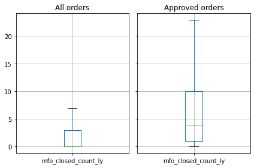

```python
field_to_compare = "mfo_closed_count_ly"
plot_boxplot(field_to_compare, df_to_compare)
```

#### Количество закрытых МФО кредитов, взятых за последний год

Банк предпочитает выдавать кредиты тем, у кого больше закрытых кредитов. Эти люди с большей верояностью вернут кредит, чем те, кто не закрывал имеющиеся кредиты или не имеет кредитной истории вообще.

Таким образом люди, которым выдавали кредит это те, кто закрывал свои прежние кредиты, кто не задерживал выплату по кредитам. При этом у человека могли быть и другие активные кредиты.

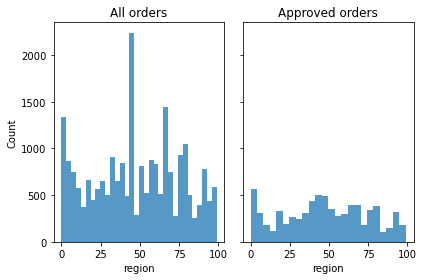

```python
plot_hist("region", df_to_compare)
```

На то выдадут ли человеку кредит не сильно влияет регион, в котором подавалась заявка. Возможно, это действительно незначимый признак. Или выбока содержит только регионы с похожим заработком. Человек из бедного района с меньшей вероятностью вернет кредит, тем более если большая часть района безработны. C другой стороны банк может давать таким людям маленькие кредиты, которые те вполне могут вернуть, которые и влияют на статистику.

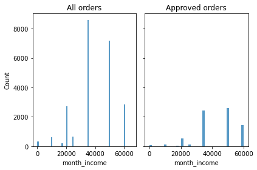

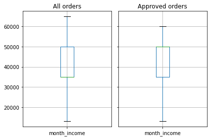

```python
plot_hist("month_income", df_to_compare)
plot_boxplot("month_income", df_to_compare)
```

Распределение заработка также не сильно отличается между двумя датасетами. Возможно, был выбран определенный диапазон заработной платы.

```python
approv_df.bad.value_counts(normalize=True)
```

```
0.000000000000000   0.729949098913193
1.000000000000000   0.270050901086807
Name: bad, dtype: float64
```

Данные не ровно распределены, поэтому при обучении стоит ориентироваться на метрику ROC-AUC

Уберем признак 'region', 'approved', 'order_id'. И создадим дамми переменные для 'work_code'.

```python
def add_work_col(df):
    df = df.join(pd.get_dummies(df['work_code'], prefix="work"))
    return df

approv_df = add_work_col(approv_df)
```

```python
cols_to_drop = ['region', 'work_5', 'approved', 'order_id', 'work_code']
approv_df.drop(columns=cols_to_drop, inplace=True)
```

Рассмотрим графики, соответствующие логарифму.

```python
def log_hist(field, df, **kwargs):
    if field == 'bad':
        return

    df_log = pd.DataFrame(df['bad'])
    df_log[field] = df[field].map(lambda x: np.log(x + 1))
    return sns.histplot(data=df_log, x=field, hue='bad', stat='count', edgecolor=None)


def plot_hist_log(field:str, df_to_compare:dict):
    plot(field, df_to_compare, log_hist)
```

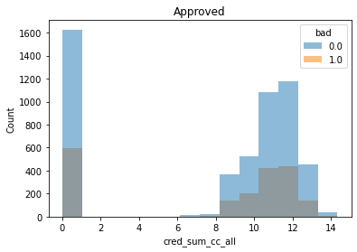

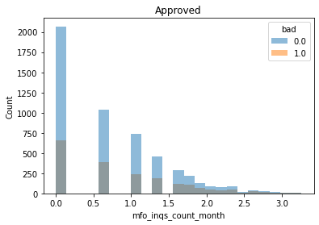

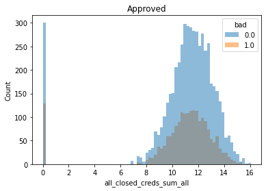

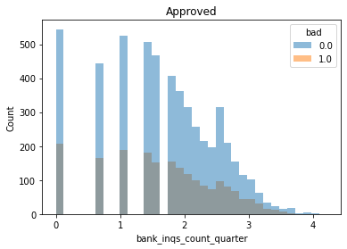

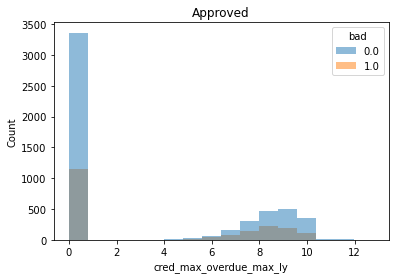

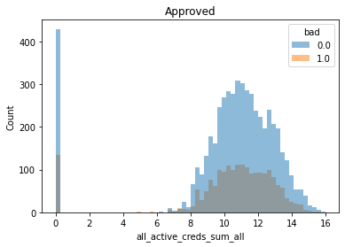

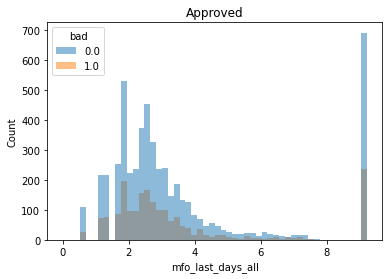

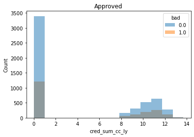

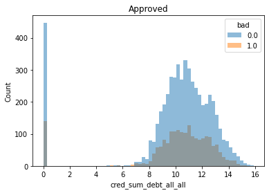

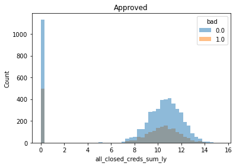

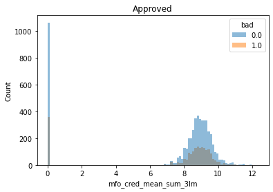

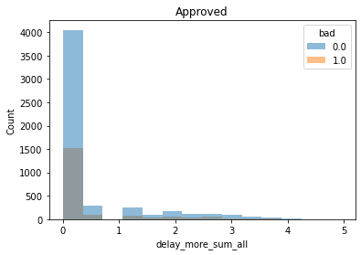

[12 more figures not shown]

```python
df_to_comp = {"Approved": approv_df}

for i in approv_df.drop(columns=['bad']).columns:
    plot_hist_log(i, df_to_comp)
```

Из графиков видно, что есть участки, на которых распределение тех, кто не вернул кредит отличается от распределения тех, кто вернул. Например люди, у которых сумма кредитов по кредитной карте (cred_sum_cc_all) находится в промежутке (exp(10) - 1; exp(12) - 1), с большей вероятностью вернут кредит.

Можно увеличить точность предсказания добавив столбцы соответствующие логарифму от других столбцов. (При добавении столбцов, соотвествующих произведению двух других или квадрату одного из столбцов, не приводит к увеличению точности)

```python
def add_log_values(df):
    # Столбцы у которых не будут вычисляться логарифмы
    drop_col = ['bad', 'work_1', 'work_2', 'work_3', 'work_4']
    columns = [field for field in df.columns if field not in drop_col]

    for index, field in enumerate(columns):
        df['log_' + field] = [np.log(i + 1) for i in df[field]]
    return df

approv_df = add_log_values(approv_df)
```

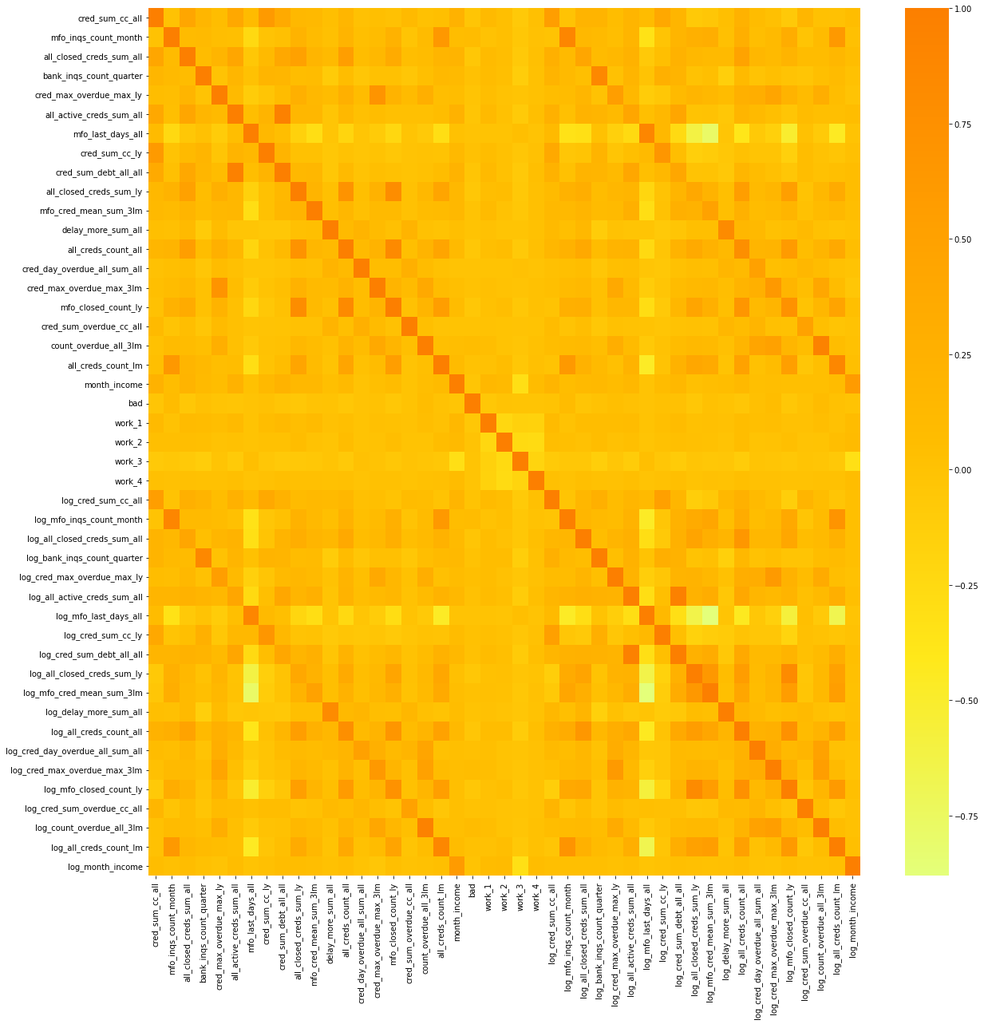

```python
corr = approv_df.corr()
plt.figure(figsize=(20, 20))
sns.heatmap(corr, cmap = 'Wistia');
```

Несколько зависимых переменных коллинеарны. Применим VIF метод, для отбора признаков.

```python
def print_corr_values(df):
    df_cor = df.corr()
    VIF = sp.linalg.inv(df_cor, check_finite=True)
    for field, vif in zip(df_cor.columns, VIF.diagonal()):
        if vif > 10:
            print(f"{field:40s} {vif}")

print_corr_values(approv_df)
```

```
all_active_creds_sum_all                 25.60105964668188
cred_sum_debt_all_all                    24.12675657051976
count_overdue_all_3lm                    12.660759608132905
log_all_active_creds_sum_all             23.167025567758827
log_mfo_last_days_all                    17.73362323395262
log_cred_sum_debt_all_all                23.103623698223583
log_mfo_closed_count_ly                  11.300901954073089
log_count_overdue_all_3lm                14.349069766653223
log_all_creds_count_lm                   11.483284586596744
```

Нашлись переменные, у которых VIF больше 10. На самом деле достаточно убрать только часть из них, чтобы избавиться от коллиниарности.

```python
cols_to_drop = ["all_active_creds_sum_all",
                "log_cred_sum_debt_all_all",
                "log_mfo_last_days_all",
                "log_count_overdue_all_3lm",
                "log_mfo_closed_count_ly"
               ]
approv_df.drop(columns=cols_to_drop, inplace=True)

print_corr_values(approv_df)
```

Нормируем данные и усредним по столбцу. В таком случае можно будет делать выводы о коэффициентах придшествующих каждому из признаков.

```python
scaler = StandardScaler()
df_trans = approv_df.drop(columns=['bad'], errors='ignore')
X = pd.DataFrame(scaler.fit_transform(df_trans), columns=df_trans.columns)

y = approv_df['bad']
```

```python
k_fold = KFold(n_splits=5, shuffle=True)

model = LogisticRegression(penalty='elasticnet', solver='saga', max_iter=4000)
fs = SelectKBest(score_func = f_classif)
pipeline = Pipeline(steps=[('anova', fs), ('lr', model)])
params = {"lr__C": [0.1, 0.5, 1, 5, 9],
          "lr__l1_ratio": [0.1, 0.5, 0.9],
          "anova__k": range(1, X.shape[1] + 1)}

cv = GridSearchCV(pipeline, param_grid=params, cv=k_fold, scoring='roc_auc', return_train_score=True)
result = cv.fit(X, y)
```

```python
result.best_score_
```

```
0.6025059656091866
```

```python
cv.best_params_
```

```
{'anova__k': 36, 'lr__C': 0.1, 'lr__l1_ratio': 0.9}
```

```python
features = pd.DataFrame(columns=['feature', 'p-value', 'coef'])
best_est = cv.best_estimator_
features['p-value'] = best_est['anova'].pvalues_
features['feature'] = best_est['anova'].feature_names_in_

# Оставляем только те, которые признаны ANOVA тестом лучшими
out = best_est['anova'].get_feature_names_out(X.columns)
features = features[features['feature'].isin(out)]

# Добавляем коэффициенты полученные методом логистической регрессии
features['coef'] = best_est['lr'].coef_[0]
features = features.append({'feature': 'intercept',
                 'p-value': 0,
                 'coef': best_est['lr'].intercept_[0]}, ignore_index=True)

features = features.sort_values("p-value").reset_index(drop=True)
features
```

|  | feature | p-value | coef |
| --- | --- | --- | --- |
| 0 | intercept | 0.000000000000000 | -1.032590504659386 |
| 1 | mfo_inqs_count_month | 0.000000000018507 | 0.076106883415731 |
| 2 | log_mfo_inqs_count_month | 0.000000000096711 | 0.143563849304501 |
| 3 | count_overdue_all_3lm | 0.000000296742509 | 0.106437473466634 |
| 4 | work_1 | 0.000002154592731 | -0.185248998044684 |
| 5 | log_cred_max_overdue_max_3lm | 0.000002457355374 | 0.092282443275235 |
| 6 | log_all_closed_creds_sum_ly | 0.000008504541024 | -0.219413163350386 |
| 7 | mfo_closed_count_ly | 0.000011316083137 | -0.160600515483302 |
| 8 | all_closed_creds_sum_all | 0.000037636072224 | -0.041619533275224 |
| 9 | all_creds_count_all | 0.000048755169535 | -0.003652997627285 |
| 10 | all_closed_creds_sum_ly | 0.000105904172191 | 0.043392800368622 |
| 11 | log_all_creds_count_all | 0.001604778181495 | 0.000000000000000 |
| 12 | log_cred_max_overdue_max_ly | 0.001731394399615 | 0.129738283473999 |
| 13 | log_all_closed_creds_sum_all | 0.002357984518148 | 0.000000000000000 |
| 14 | month_income | 0.004458191913598 | -0.057690441573156 |
| 15 | log_cred_day_overdue_all_sum_all | 0.021375655583825 | 0.025028270022546 |
| 16 | cred_sum_cc_all | 0.036086210060150 | -0.055616959345806 |
| 17 | cred_sum_debt_all_all | 0.041796751873040 | -0.024010521243656 |
| 18 | log_all_creds_count_lm | 0.077146474945031 | 0.006932000884048 |
| 19 | log_cred_sum_cc_ly | 0.096757571100931 | 0.005663040082622 |
| 20 | work_4 | 0.115655112490152 | -0.110725759297619 |
| 21 | log_mfo_cred_mean_sum_3lm | 0.142141755313190 | 0.078028390773727 |
| 22 | cred_max_overdue_max_ly | 0.157088358716784 | -0.172556175449882 |
| 23 | work_3 | 0.183229801507430 | -0.114381376299526 |
| 24 | cred_sum_cc_ly | 0.230816001040226 | 0.060842472606292 |
| 25 | work_2 | 0.267856080724478 | -0.108695119507087 |
| 26 | mfo_last_days_all | 0.268347726507798 | -0.026196232613782 |
| 27 | bank_inqs_count_quarter | 0.312384557628437 | 0.003092746560844 |
| 28 | log_all_active_creds_sum_all | 0.400936428241085 | 0.016480186643714 |
| 29 | mfo_cred_mean_sum_3lm | 0.403715800848451 | -0.009137701080811 |
| 30 | cred_day_overdue_all_sum_all | 0.420584354255387 | -0.030373974459027 |
| 31 | log_bank_inqs_count_quarter | 0.577001931702928 | -0.009494138880015 |
| 32 | all_creds_count_lm | 0.590290624325356 | 0.000000000000000 |
| 33 | cred_max_overdue_max_3lm | 0.609009576969460 | -0.008218042061296 |
| 34 | cred_sum_overdue_cc_all | 0.619391861050863 | 0.000000000000000 |
| 35 | log_delay_more_sum_all | 0.796361787457285 | 0.003468552047373 |
| 36 | log_cred_sum_overdue_cc_all | 0.883102045400367 | 0.000000000000000 |

Первые 18 признаков являются статистичиски значимыми

#### Придумать/найти алгоритм разметки отклоненных (bad=NaN) заявок.

Если заявка была отклонена, значит банк посчитал, что человек не вернет кредит. Поэтому все, кому не одобрили кредит,  
не вернули бы его bad = 1.

```python
train_copy = train_df.copy()
```

```python
train_copy.loc[train_copy.approved == 0, "bad"] = 1
train_copy.drop(columns=['approved', 'order_id', 'region'], inplace=True, errors='ignore')
```

```python
train_copy = add_work_col(train_copy)
train_copy.drop(columns=['work_code'], inplace=True)

train_copy = add_log_values(train_copy)
```

```python
print_corr_values(train_copy)
```

```
count_overdue_all_3lm                    11.46882838945209
work_1                                   67675607972230.336
work_2                                   137425856883985.28
work_3                                   136453358376674.28
work_4                                   107740748612662.03
work_5                                   88978924018247.52
log_mfo_last_days_all                    24.505541608479064
log_all_creds_count_all                  10.39348535237997
log_mfo_closed_count_ly                  12.859517151779375
log_count_overdue_all_3lm                15.122401716529982
log_all_creds_count_lm                   12.256498872766201
```

```python
train_copy.drop(columns=['work_1',
                         'log_mfo_last_days_all',
                         'log_count_overdue_all_3lm',
                         'log_mfo_closed_count_ly'
                        ], inplace=True)

print_corr_values(train_copy)
```

```python
scaler = StandardScaler()
df_trans = train_copy.drop(columns=['bad'], errors='ignore')
X = pd.DataFrame(scaler.fit_transform(df_trans), columns=df_trans.columns)

y = train_copy['bad']
```

```python
k_fold = KFold(n_splits=5, shuffle=True)

model = LogisticRegression(penalty='elasticnet', solver='saga', max_iter=4000)
fs = SelectKBest(score_func = f_classif)
pipeline = Pipeline(steps=[('anova', fs), ('lr', model)])
params = {"lr__C": [0.1, 0.5, 1, 5, 9],
          "lr__l1_ratio": [0.1, 0.5, 0.9],
          "anova__k": range(1, X.shape[1] + 1)}

cv_2 = GridSearchCV(pipeline, param_grid=params, cv=k_fold, scoring='roc_auc', return_train_score=True)
result_2 = cv_2.fit(X, y)
```

```python
result_2.best_score_
```

```
0.9077649074944164
```

```python
cv_2.best_params_
```

```
{'anova__k': 42, 'lr__C': 0.1, 'lr__l1_ratio': 0.5}
```

```python
features_2 = pd.DataFrame(columns=['feature', 'p-value', 'coef'])
best_est = cv_2.best_estimator_
features_2['p-value'] = best_est['anova'].pvalues_
features_2['feature'] = best_est['anova'].feature_names_in_

# Оставляем только те, которые признаны ANOVA тестом лучшими
out = best_est['anova'].get_feature_names_out(X.columns)
features_2 = features_2[features_2['feature'].isin(out)]

# Добавляем коэффициенты полученные методом логистической регрессии
features_2['coef'] = best_est['lr'].coef_[0]
features_2 = features_2.append({'feature': 'intercept',
                 'p-value': 0,
                 'coef': best_est['lr'].intercept_[0]}, ignore_index=True)

features_2 = features_2.sort_values("p-value").reset_index(drop=True)
features_2
```

|  | feature | p-value | coef |
| --- | --- | --- | --- |
| 0 | intercept | 0.000000000000000 | 2.298989762082165 |
| 1 | log_all_closed_creds_sum_all | 0.000000000000000 | -0.234922370081410 |
| 2 | log_bank_inqs_count_quarter | 0.000000000000000 | -0.378533663595558 |
| 3 | all_creds_count_lm | 0.000000000000000 | 0.022342601473881 |
| 4 | log_all_active_creds_sum_all | 0.000000000000000 | 0.314011743749151 |
| 5 | log_cred_sum_cc_ly | 0.000000000000000 | -0.128783467864897 |
| 6 | mfo_closed_count_ly | 0.000000000000000 | -0.153586792422251 |
| 7 | log_cred_sum_debt_all_all | 0.000000000000000 | -0.852885050276343 |
| 8 | mfo_cred_mean_sum_3lm | 0.000000000000000 | -0.023422322505184 |
| 9 | log_all_closed_creds_sum_ly | 0.000000000000000 | -0.419125939724800 |
| 10 | log_mfo_cred_mean_sum_3lm | 0.000000000000000 | -0.110847760228386 |
| 11 | log_all_creds_count_all | 0.000000000000000 | -0.827861206281314 |
| 12 | bank_inqs_count_quarter | 0.000000000000000 | 0.147148765620095 |
| 13 | log_cred_day_overdue_all_sum_all | 0.000000000000000 | 1.158744436530640 |
| 14 | log_all_creds_count_lm | 0.000000000000000 | -0.030505623590183 |
| 15 | all_closed_creds_sum_ly | 0.000000000000000 | 0.109480505434303 |
| 16 | all_creds_count_all | 0.000000000000000 | 0.185269284987723 |
| 17 | log_delay_more_sum_all | 0.000000000000000 | 0.532058328128438 |
| 18 | log_mfo_inqs_count_month | 0.000000000000000 | 0.018435119591561 |
| 19 | cred_sum_cc_ly | 0.000000000000000 | 0.000000000000000 |
| 20 | log_cred_sum_cc_all | 0.000000000000000 | -0.167547463404749 |
| 21 | cred_sum_debt_all_all | 0.000000000000000 | 0.021716368139649 |
| 22 | cred_day_overdue_all_sum_all | 0.000000000000000 | -0.118031547541002 |
| 23 | month_income | 0.000000000000000 | -0.201932577769315 |
| 24 | cred_sum_cc_all | 0.000000000000000 | -0.003879340955598 |
| 25 | mfo_last_days_all | 0.000000000000000 | -0.274232221274758 |
| 26 | mfo_inqs_count_month | 0.000000000000000 | 0.132434838980059 |
| 27 | all_active_creds_sum_all | 0.000000000000000 | 0.032502139471877 |
| 28 | delay_more_sum_all | 0.000000000000000 | -0.079690170395233 |
| 29 | all_closed_creds_sum_all | 0.000000000000000 | 0.000000000000000 |
| 30 | log_cred_sum_overdue_cc_all | 0.000000000000000 | 0.352155995301500 |
| 31 | work_3 | 0.000000000000000 | 0.060008051031403 |
| 32 | work_2 | 0.000000000000000 | 0.072141679070029 |
| 33 | work_5 | 0.000000000000000 | 0.080313239185380 |
| 34 | log_work_5 | 0.000000000000000 | 0.080313239185388 |
| 35 | log_month_income | 0.000000000000000 | 0.025000596654088 |
| 36 | cred_sum_overdue_cc_all | 0.000000000000000 | 0.173115941068439 |
| 37 | count_overdue_all_3lm | 0.000000000000000 | 0.144013485606277 |
| 38 | cred_max_overdue_max_3lm | 0.000019720076163 | -0.081164960745170 |
| 39 | log_cred_max_overdue_max_3lm | 0.000209673532225 | 0.089188666589557 |
| 40 | work_4 | 0.000415923532099 | 0.056601252500065 |
| 41 | log_cred_max_overdue_max_ly | 0.006498322222886 | 0.115620451401205 |
| 42 | cred_max_overdue_max_ly | 0.015919633757003 | 0.006702708363320 |

Точность намного выше, чем при использовании только тех, кому был одобрен кредит. Это связано с тем, что при выборе тех, кому выдать кредит банк также анализировал все имеющиеся данные, но так как модель не давала стопроцентного ответа на вопрос "вернет ли человек кредит", кредит был выдан тем, кто его в результате не вернул. Среди тех, кому был выдан кредит намного сложнее выбрать тех, кому на самом деле не стоило выдавать кредит, они обработаны банком, а значит есть малая вероятность, что они все таки вернут кредит.

При этом для анализа на тестовых данных нельзя использовать первую модель, так как там для обучения используются только часть клиентов, те, кому был одобрен кредит. Эта модель лишь помогает понять, какие переменные были не учтены банком или были учтены, но не слишком строго. Если предсказывать значения, используя первую модель, не будут учтены признаки, которые были учтен банком при классификации и предсказании переменной approved.

Выделим какие переменные использовались в первый модели, а какие во второй.

```python
var_1 = set([i.replace("log_", "") for i in features.feature])
```

```python
var_2 = set([i.replace("log_", "") for i in features_2.feature])
```

```python
bank_feat = [i for i in var_2 if i not in var_1]
mut_feat = [i for i in var_2 if i in var_1]
new_feat = [i for i in var_1 if i not in var_2]
```

```python
bank_feat
```

```
['work_5']
```

```python
new_feat
```

```
['work_1']
```

Выше представлены признаки, которые использовались при обучении только первой модели. Это связано с тем, что в первой модели мы убирали work_5, а во второй work_1. Значит предположение выссказанное выше не верно. На самом деле и в первой, и во второй моделях использовались одни и те же признаки (мы не учитываем использовался ли лоарифм от признака или сам признак).

### Предскажем тестовые данные, используя вторую модель

Сначала обучим модель используя параметры полученые GridSearchCV

```python
tr_df = train_copy[features_2.feature[1:]]
df_trans = tr_df.drop(columns=['bad'], errors='ignore')
X_ = pd.DataFrame(scaler.fit_transform(df_trans), columns=df_trans.columns)

y_ = train_copy['bad']
```

```python
model = LogisticRegression(penalty='elasticnet', solver='saga', max_iter=4000, C=0.1, l1_ratio=0.5)
model.fit(X_, y_)
```

```
LogisticRegression(C=0.1, l1_ratio=0.5, max_iter=4000, penalty='elasticnet',
                   solver='saga')
```

```python
test_df = add_work_col(test_df)
```

```python
test_df = add_log_values(test_df)
```

```python
test_df = test_df[tr_df.columns]
```

```python
df_trans = test_df.drop(columns=['bad'], errors='ignore')
X_test = pd.DataFrame(scaler.transform(df_trans), columns=df_trans.columns)
```

```python
y_test = model.predict(X_test)
```

```python
result = X_test.copy()
result['bad'] = y_test
result.to_csv('result.csv', index=False)
```